# Factors Affecting Students Performance in Exam/Test

## by Benjamin Ogbonna

### Last updated 23 August, 2022

## Investigation Overview

> In this investigation, I wanted to look at some of the factors that contribute or affect students performance in exam. Our main focus will be on Parental level of education, test preparation course, race/ethnicity and lunch (standard or free/reduced).

## Dataset Overview

> This dataset consist of 1000 grades of student who took an exam/test with the following attributes: 0 gender  
> 1 race/ethnicity  
> 2 parental level of education  
> 3 lunch  
> 4 test preparation course  
> 5 math score  
> 6 reading score  
> 7 writing score  
> This data was gotten from [kaggle](https://www.kaggle.com/datasets/spscientist/students-performance-in-exams), a public data repository.

|  | gender | race/ethnicity | parental level of education | lunch | test preparation course | math score | reading score | writing score |
| --- | --- | --- | --- | --- | --- | --- | --- | --- |
| 0 | female | group B | bachelor's degree | standard | none | 72 | 72 | 74 |
| 1 | female | group C | some college | standard | completed | 69 | 90 | 88 |
| 2 | female | group B | master's degree | standard | none | 90 | 95 | 93 |
| 3 | male | group A | associate's degree | free/reduced | none | 47 | 57 | 44 |
| 4 | male | group C | some college | standard | none | 76 | 78 | 75 |
| ... | ... | ... | ... | ... | ... | ... | ... | ... |
| 995 | female | group E | master's degree | standard | completed | 88 | 99 | 95 |
| 996 | male | group C | high school | free/reduced | none | 62 | 55 | 55 |
| 997 | female | group C | high school | free/reduced | completed | 59 | 71 | 65 |
| 998 | female | group D | some college | standard | completed | 68 | 78 | 77 |
| 999 | female | group D | some college | free/reduced | none | 77 | 86 | 86 |

1000 rows × 8 columns

### So After adding two columns, total_score and grade our dataset looks better.

|  | gender | race/ethnicity | parental level of education | lunch | test preparation course | math score | reading score | writing score | total_score | grade |
| --- | --- | --- | --- | --- | --- | --- | --- | --- | --- | --- |
| 0 | female | group B | bachelor's degree | standard | none | 72 | 72 | 74 | 218 | C |
| 1 | female | group C | some college | standard | completed | 69 | 90 | 88 | 247 | B |
| 2 | female | group B | master's degree | standard | none | 90 | 95 | 93 | 278 | A |
| 3 | male | group A | associate's degree | free/reduced | none | 47 | 57 | 44 | 148 | F |
| 4 | male | group C | some college | standard | none | 76 | 78 | 75 | 229 | C |

## Distribution of Gender

Out plot show there were more females than males who took the test.

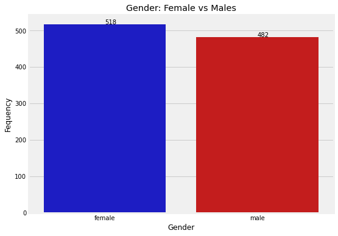

## Distribustion of Grades (A, B, C, D, F)

Many student got below average. Of our 1000 students, 52 got A, 146 got B, 256 got D, 261 got C and 285 got F

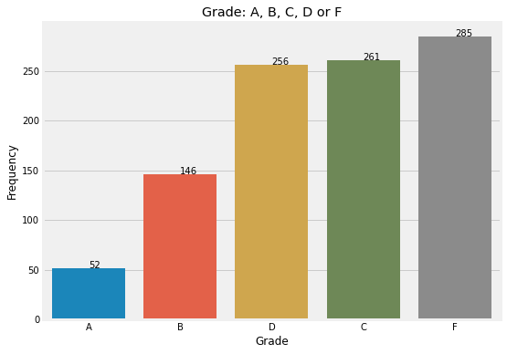

```
A     52
B    146
D    256
C    261
F    285
Name: grade, dtype: int64
```

## Grade and Parental level of education

> Students whose parents completed just high school did very poor in the test, they got more F's and less than 10 A's. And students whose parents are masters holders did better. This therefore shows that educated parents plays or contribute to the success of their children (most times).

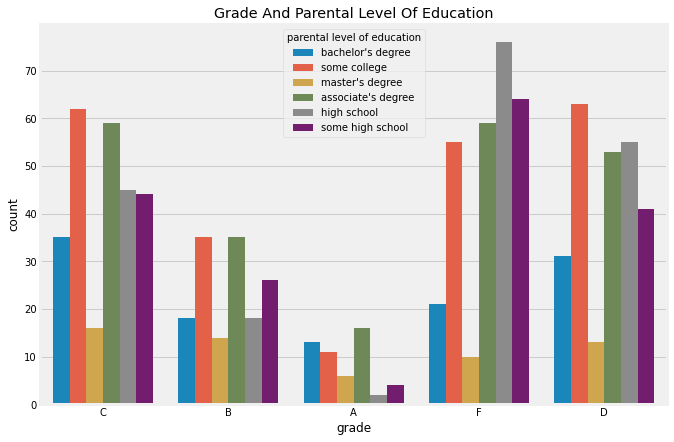

## Grade and Test preparation course

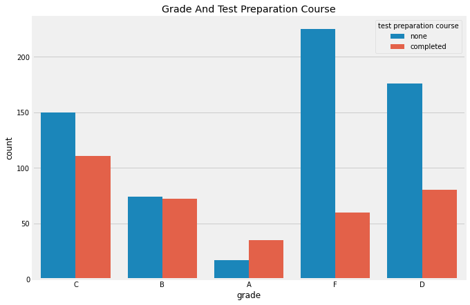

## Grade and Race/ethnicity

> Students from Group B seems to be around average in all grades, while those of group C seems to get high pass and high fail too (looking at grade A and F). I think Group E did better in terms of grade because they got many A's, B's and lesser F's and D's.

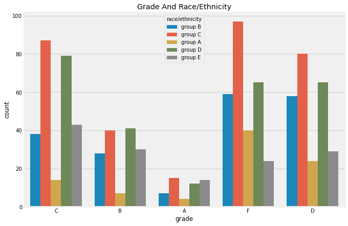

## Grade and Lunch

> Students with standard lunch did quite better than those with free/reduced lunch. With less than 10 students who took free/reduced lunch getting an A while about 50 with standard lunch got an A. Also over 150 student with free/reduced lunch got an F.

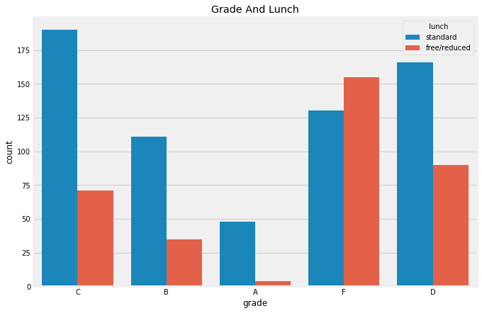